# Data Manipulation

Christina Maimone

# Setup

This session covers some useful functions and gives examples of how to accomplish some common data tasks in R.

Reading in the policing data:

```r
evp <- read.csv("data/ev_police_jan.csv")
```

Note: Evanston police data comes from the [Stanford Open Policing Project](https://openpolicing.stanford.edu/data/). This is a small subset of data: just January 2017.

And we’ll use the penguins data for some exercises too

```r
library(palmerpenguins)
```

# Useful functions

## ifelse

`ifelse()` allows you to change the values of a vector based on a conditional test. It’s useful for recoding data, and you can use it in situations where you don’t want to change the underlying data.

The format is:

```r
ifelse(test_condition, value_if_true, value_if_false)
```

where the test condition is usually some comparison or operation on a vector - anything that results in TRUE or FALSE values

```r
x <- c(-1, 2, 3, -5, 3, NA, -4, 6)
x >= 0
```

```
## [1] FALSE  TRUE  TRUE FALSE  TRUE    NA FALSE  TRUE
```

```r
ifelse(x >= 0, x, 0)  # replace negative values with 0, leave others alone
```

```
## [1]  0  2  3  0  3 NA  0  6
```

```r
ifelse(is.na(x), 0, x)  # replace missing values with 0, leave others alone
```

```
## [1] -1  2  3 -5  3  0 -4  6
```

```r
ifelse(x %% 2 == 0, "even", "odd")  ## remainder of dividing x by 2 is 0
```

```
## [1] "odd"  "even" "odd"  "odd"  "odd"  NA     "even" "even"
```

There’s also the useful `replace_na()` function in the tidyr package and `na_if()` in dplyr.

## EXERCISE

Where the value in the vector below is positive, take the square root. Where it is negative, substitute in `NA`.

```r
y <- c(4, -1, 3, 6, -7, 10, 20)
```

## %in%

`%in%` returns TRUE if the value on the left is in the vector on the right, FALSE otherwise. Unlike `==`, if the value on the left is `NA`, it will return FALSE unless `NA` is also in the vector on the right:

```r
x <- c(-1, 2, 3, -5, 3, NA, -4, 6)
x %in% c(1, 2, 3)
```

```
## [1] FALSE  TRUE  TRUE FALSE  TRUE FALSE FALSE FALSE
```

```r
x == 1 | x == 2 | x == 3
```

```
## [1] FALSE  TRUE  TRUE FALSE  TRUE    NA FALSE FALSE
```

```r
state.name  # built-in vector in R
```

```
##  [1] "Alabama"        "Alaska"         "Arizona"        "Arkansas"
##  [5] "California"     "Colorado"       "Connecticut"    "Delaware"
##  [9] "Florida"        "Georgia"        "Hawaii"         "Idaho"
## [13] "Illinois"       "Indiana"        "Iowa"           "Kansas"
## [17] "Kentucky"       "Louisiana"      "Maine"          "Maryland"
## [21] "Massachusetts"  "Michigan"       "Minnesota"      "Mississippi"
## [25] "Missouri"       "Montana"        "Nebraska"       "Nevada"
## [29] "New Hampshire"  "New Jersey"     "New Mexico"     "New York"
## [33] "North Carolina" "North Dakota"   "Ohio"           "Oklahoma"
## [37] "Oregon"         "Pennsylvania"   "Rhode Island"   "South Carolina"
## [41] "South Dakota"   "Tennessee"      "Texas"          "Utah"
## [45] "Vermont"        "Virginia"       "Washington"     "West Virginia"
## [49] "Wisconsin"      "Wyoming"
```

```r
ifelse(state.name %in% c("Alaska", "Hawaii"), NA, state.name)
```

```
##  [1] "Alabama"        NA               "Arizona"        "Arkansas"
##  [5] "California"     "Colorado"       "Connecticut"    "Delaware"
##  [9] "Florida"        "Georgia"        NA               "Idaho"
## [13] "Illinois"       "Indiana"        "Iowa"           "Kansas"
## [17] "Kentucky"       "Louisiana"      "Maine"          "Maryland"
## [21] "Massachusetts"  "Michigan"       "Minnesota"      "Mississippi"
## [25] "Missouri"       "Montana"        "Nebraska"       "Nevada"
## [29] "New Hampshire"  "New Jersey"     "New Mexico"     "New York"
## [33] "North Carolina" "North Dakota"   "Ohio"           "Oklahoma"
## [37] "Oregon"         "Pennsylvania"   "Rhode Island"   "South Carolina"
## [41] "South Dakota"   "Tennessee"      "Texas"          "Utah"
## [45] "Vermont"        "Virginia"       "Washington"     "West Virginia"
## [49] "Wisconsin"      "Wyoming"
```

## EXERCISE

Select the rows from the `evp` data where the vehicle make is one of FIAT, DATS, GEO, JAGU, or PEUG

## paste

The `paste()` function is used to join pieces of text:

```r
paste("Christina", "Maimone")
```

```
## [1] "Christina Maimone"
```

The default separator between the strings is a space, but you can change it:

```r
paste("Christina", "Maimone", sep="---")
```

```
## [1] "Christina---Maimone"
```

But, I frequently want to join strings with no space between them:

```r
paste("Christina", "Maimone", sep="")
```

```
## [1] "ChristinaMaimone"
```

There’s a shortcut for this:

```r
paste0("Christina", "Maimone")
```

```
## [1] "ChristinaMaimone"
```

## EXERCISE

`state.abb` has two-letter abbreviations for US states. `state.region` has the region for each US state. Use `paste()` to join the info from these two vectors together, so the output has entries that look like:

```
"AL: South"         "AK: West"          "AZ: West"          "AR: South"  ...
```

## seq

`seq()` is used to generate sequences of numbers. You can specify the interval between values or how many values you want.

```r
seq(from=1, to=10, by=2)
```

```
## [1] 1 3 5 7 9
```

Note that the sequence output will only have values that are <= the “to” value.

```r
seq(0, 10, length.out=4)
```

```
## [1]  0.000000  3.333333  6.666667 10.000000
```

```r
seq(0, 1, .1)
```

```
##  [1] 0.0 0.1 0.2 0.3 0.4 0.5 0.6 0.7 0.8 0.9 1.0
```

## EXERCISE

Use the `seq()` function to select every 5th row from `state.x77` (it’s a matrix built in to R - you can index it like a data frame).

Things you need to figure out: how do you know what the sequence should go to? How do you use the result of seq() to then select the rows?

# Dates

In most cases, when you read data with dates/times in it into R, it will be read in as character (text) data:

```r
str(evp)
```

```
## 'data.frame':    1409 obs. of  29 variables:
##  $ raw_row_number           : int  11249746 11249747 11249748 11249749 11249750 11249751 11249752 11249753 11249754 11249755 ...
##  $ date                     : chr  "2017-01-01" "2017-01-01" "2017-01-01" "2017-01-01" ...
##  $ time                     : chr  "00:56:00" "04:43:00" "09:21:00" "10:04:00" ...
##  $ location                 : int  60202 60643 60625 60068 60645 60645 60626 60202 60656 60626 ...
##  $ beat                     : chr  "72" "71" "78" "75" ...
##  $ subject_age              : logi  NA NA NA NA NA NA ...
##  $ subject_race             : chr  "white" "black" "black" "white" ...
##  $ subject_sex              : chr  "male" "male" "female" "male" ...
##  $ department_id            : int  13178 13178 13178 13178 13178 13178 13178 13178 13178 13178 ...
##  $ department_name          : chr  "EVANSTON POLICE" "EVANSTON POLICE" "EVANSTON POLICE" "EVANSTON POLICE" ...
##  $ type                     : chr  "vehicular" "vehicular" "vehicular" "vehicular" ...
##  $ violation                : chr  "Moving Violation: Traffic Sign or Signal" "Equipment" "License Plate/Registration" "Moving Violation: Traffic Sign or Signal" ...
##  $ citation_issued          : logi  FALSE FALSE FALSE FALSE TRUE TRUE ...
##  $ warning_issued           : logi  TRUE TRUE TRUE TRUE FALSE FALSE ...
##  $ outcome                  : chr  "warning" "warning" "warning" "warning" ...
##  $ contraband_found         : logi  NA NA NA NA NA NA ...
##  $ contraband_drugs         : logi  NA NA NA NA NA NA ...
##  $ contraband_weapons       : logi  NA NA NA NA NA NA ...
##  $ search_conducted         : logi  FALSE FALSE FALSE FALSE FALSE FALSE ...
##  $ search_person            : logi  FALSE FALSE FALSE FALSE FALSE FALSE ...
##  $ search_vehicle           : logi  FALSE FALSE FALSE FALSE FALSE FALSE ...
##  $ search_basis             : chr  NA NA NA NA ...
##  $ reason_for_stop          : chr  "Moving Violation: Traffic Sign or Signal" "Equipment" "License Plate/Registration" "Moving Violation: Traffic Sign or Signal" ...
##  $ vehicle_make             : chr  "TOYT" "NISS" "CHEV" "NISS" ...
##  $ vehicle_year             : int  2006 2015 2011 2009 2010 2005 2011 2009 2007 2011 ...
##  $ raw_DriverRace           : int  1 2 2 1 1 1 2 1 1 2 ...
##  $ raw_ReasonForStop        : int  1 2 3 1 1 1 1 1 1 1 ...
##  $ raw_TypeOfMovingViolation: int  4 0 0 4 1 6 3 1 1 1 ...
##  $ raw_ResultOfStop         : int  3 3 3 2 1 1 1 2 2 2 ...
```

If you want to use this information in a visualization, or aggregate data by month, or use the date information in other ways, you’ll need to convert this information into an object that knows about dates and times.

One way to do this is by using the readr package (part of tidyverse) to import your data,. There is a `read_csv()` function instead of a `read.csv()` function. It will try to convert things that look like dates to Date objects if it can; you can also specify that a column contains dates/times when you import the data with the readr package.

```r
library(readr)

readr_evp <- read_csv("data/ev_police_jan.csv")
str(readr_evp)
```

```
## spec_tbl_df [1,409 × 29] (S3: spec_tbl_df/tbl_df/tbl/data.frame)
##  $ raw_row_number           : num [1:1409] 11249746 11249747 11249748 11249749 11249750 ...
##  $ date                     : Date[1:1409], format: "2017-01-01" "2017-01-01" ...
##  $ time                     : 'hms' num [1:1409] 00:56:00 04:43:00 09:21:00 10:04:00 ...
##   ..- attr(*, "units")= chr "secs"
##  $ location                 : num [1:1409] 60202 60643 60625 60068 60645 ...
##  $ beat                     : num [1:1409] 72 71 78 75 71 78 78 72 72 72 ...
##  $ subject_age              : logi [1:1409] NA NA NA NA NA NA ...
##  $ subject_race             : chr [1:1409] "white" "black" "black" "white" ...
##  $ subject_sex              : chr [1:1409] "male" "male" "female" "male" ...
##  $ department_id            : num [1:1409] 13178 13178 13178 13178 13178 ...
##  $ department_name          : chr [1:1409] "EVANSTON POLICE" "EVANSTON POLICE" "EVANSTON POLICE" "EVANSTON POLICE" ...
##  $ type                     : chr [1:1409] "vehicular" "vehicular" "vehicular" "vehicular" ...
##  $ violation                : chr [1:1409] "Moving Violation: Traffic Sign or Signal" "Equipment" "License Plate/Registration" "Moving Violation: Traffic Sign or Signal" ...
##  $ citation_issued          : logi [1:1409] FALSE FALSE FALSE FALSE TRUE TRUE ...
##  $ warning_issued           : logi [1:1409] TRUE TRUE TRUE TRUE FALSE FALSE ...
##  $ outcome                  : chr [1:1409] "warning" "warning" "warning" "warning" ...
##  $ contraband_found         : logi [1:1409] NA NA NA NA NA NA ...
##  $ contraband_drugs         : logi [1:1409] NA NA NA NA NA NA ...
##  $ contraband_weapons       : logi [1:1409] NA NA NA NA NA NA ...
##  $ search_conducted         : logi [1:1409] FALSE FALSE FALSE FALSE FALSE FALSE ...
##  $ search_person            : logi [1:1409] FALSE FALSE FALSE FALSE FALSE FALSE ...
##  $ search_vehicle           : logi [1:1409] FALSE FALSE FALSE FALSE FALSE FALSE ...
##  $ search_basis             : chr [1:1409] NA NA NA NA ...
##  $ reason_for_stop          : chr [1:1409] "Moving Violation: Traffic Sign or Signal" "Equipment" "License Plate/Registration" "Moving Violation: Traffic Sign or Signal" ...
##  $ vehicle_make             : chr [1:1409] "TOYT" "NISS" "CHEV" "NISS" ...
##  $ vehicle_year             : num [1:1409] 2006 2015 2011 2009 2010 ...
##  $ raw_DriverRace           : num [1:1409] 1 2 2 1 1 1 2 1 1 2 ...
##  $ raw_ReasonForStop        : num [1:1409] 1 2 3 1 1 1 1 1 1 1 ...
##  $ raw_TypeOfMovingViolation: num [1:1409] 4 0 0 4 1 6 3 1 1 1 ...
##  $ raw_ResultOfStop         : num [1:1409] 3 3 3 2 1 1 1 2 2 2 ...
##  - attr(*, "spec")=
##   .. cols(
##   ..   raw_row_number = col_double(),
##   ..   date = col_date(format = ""),
##   ..   time = col_time(format = ""),
##   ..   location = col_double(),
##   ..   beat = col_double(),
##   ..   subject_age = col_logical(),
##   ..   subject_race = col_character(),
```

[output cut: 9 more lines]

```
##   ..   contraband_drugs = col_logical(),
##   ..   contraband_weapons = col_logical(),
##   ..   search_conducted = col_logical(),
##   ..   search_person = col_logical(),
##   ..   search_vehicle = col_logical(),
##   ..   search_basis = col_character(),
##   ..   reason_for_stop = col_character(),
##   ..   vehicle_make = col_character(),
##   ..   vehicle_year = col_double(),
##   ..   raw_DriverRace = col_double(),
##   ..   raw_ReasonForStop = col_double(),
##   ..   raw_TypeOfMovingViolation = col_double(),
##   ..   raw_ResultOfStop = col_double()
##   .. )
##  - attr(*, "problems")=<externalptr>
```

But, if you aren’t using readr, or need to perform other operations with dates, you can do so with the lubridate package (also from tidyverse).

```r
library(lubridate)
```

It has a series of functions that are named like:

```r
ymd()
ymd_hms()
dmy()
dmy_h()
mdy()
```

And so on, where y=year, m (in the first part)=month, d=day, h=hour, m (in the second part)=minute, s=second. With the function name, you are specifying which parts of a date or time appear in the text you’re converting and what order the different parts appear in. You can ignore all of the delimiters and other components like dashes, slashes, or even no delimiter at all. lubridate can handle most cases:

```r
my_dates <- c("1/13/2020","1/13/20", "01132020", "1-13-2020", "Jan 13 2020", "Jan. 13, 2020")
class(my_dates)
```

```
## [1] "character"
```

```r
my_dates <- mdy(my_dates)
class(my_dates)
```

```
## [1] "Date"
```

Without lubridate, you have to specify the format of the datetime object with POSIX standards (see the help page for strftime).

## EXERCISE

Make two new columns in the evp data frame:

- Date (capitalized) that converts the date column to a Date type - you can use a function with just the date components, such as mdy(), dmy(), or ymd()
- datetime: paste (concatenate) the date and time columns together, and then convert the joined string to a datetime object (if you’re checking, it will be of type “POSIXct”) - you’ll need to use a function with both date and time components

## Example

Now that we have the data information in a date-type format, we can ask questions such as: what day of the week had the most traffic stops?

```r
wday(evp$Date, label=TRUE)  # day of the week of the stop (named)
table(wday(evp$Date, label=TRUE))  # tally these
```

The data we have is just for January, which means there are more instances of some days of the week than others. So we want to normalize by the number of Mondays, Tuesdays, etc.

```r
seq.Date(ymd("2017-01-01"), ymd("2017-01-31"), 1)  # days in January 2017
wday(seq.Date(ymd("2017-01-01"), ymd("2017-01-31"), 1), label=TRUE)  ## as days of the week
table(wday(seq.Date(ymd("2017-01-01"), ymd("2017-01-31"), 1), label=TRUE))  # tallied
table(wday(evp$Date, label=TRUE)) / table(wday(seq.Date(ymd("2017-01-01"), ymd("2017-01-31"), 1), label=TRUE)) # together
```

# Factors

This is because the days of the week were returned as a ordered factor – a categorical variable.

Factors are variables with text labels, but the set of values (called levels) that are allowed for the variable is limited, and the values optionally can have a specific order to them.

## Why Do I Need Factors?

Let’s look at what happens with the days of the week if they are NOT a factor – just character (text) data instead:

```r
evp$Date <- ymd(evp$date)  # did this in the exercise above
evp$dow <- as.character(wday(evp$Date, label=TRUE))  # as.character makes it not a factor - just text data
table(evp$dow)
```

```
##
## Fri Mon Sat Sun Thu Tue Wed
## 213 235 173 142 179 270 197
```

The days are in alphabetical order, not day of the week order!

Or, let’s make a plot of the reported race of the people stopped:

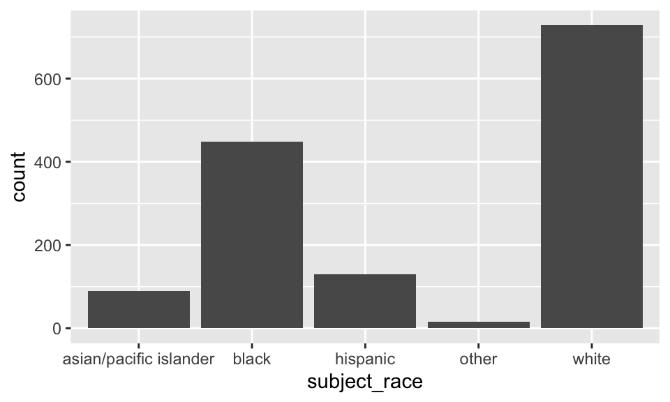

```r
library(ggplot2)
ggplot(evp, aes(x=subject_race)) +
  geom_bar()
```

This is OK, but ideally the categories of a bar chart would either be in a meaningful order, or ordered by their frequency.

## Make a Factor

In both cases above, the character data is converted into a factor in the process of making a table or the plot. If we don’t like the default ordering, we can control it by explicitly making the variable a factor ourselves and setting the levels.

The default order is alphabetical order, which is dependent on the locale of your computer (language and location settings).

```r
evp$subject_race <- factor(evp$subject_race,
                           levels=c("white", "black", "hispanic", "asian/pacific islander", "other"))
head(evp$subject_race)
```

```
## [1] white black black white white white
## Levels: white black hispanic asian/pacific islander other
```

```r
table(evp$subject_race)
```

```
##
##                  white                  black               hispanic
##                    728                    448                    129
## asian/pacific islander                  other
##                     89                     15
```

Here, we specified the levels in order, so they will appear that way. But we didn’t say that any category is greater than or less than another – there isn’t an inherit order to the categories, even though we did set the order that they will display in.

There aren’t many cases where you’re likely to do operations on a factor and actually need R to know which category is greater than another, but you can indicate that the factor is ordered if needed (ordered categorical data instead of just categorical data). Answers to scales from surveys is one case where ordered factors can be useful.

```r
answers <- c("Very unhappy", "Somewhat unhappy", "Somewhat happy", "Very happy",
             "Somewhat unhappy", "Somewhat happy", "Somewhat unhappy", "Somewhat happy",
             "Very happy", "Very unhappy", "Very happy", "Very happy")
answers <- factor(answers,
                  levels = c("Very unhappy", "Somewhat unhappy", "Somewhat happy", "Very happy"),
                  ordered = TRUE)
answers
```

```
##  [1] Very unhappy     Somewhat unhappy Somewhat happy   Very happy
##  [5] Somewhat unhappy Somewhat happy   Somewhat unhappy Somewhat happy
##  [9] Very happy       Very unhappy     Very happy       Very happy
## Levels: Very unhappy < Somewhat unhappy < Somewhat happy < Very happy
```

You can see here that the levels are printed with less than signs `<` indicating a formal ordering that can be used in boolean comparisons.

## EXERCISE

Convert the vector below to a factor. Set the levels in an intentional order.

```r
directions <- c("east", "west", "east", "south", "north", "north", "west", "north", "east")
```

## forcats Package

The forcats package has a number of functions to help you work with factors – for example, reordering the levels of a factor based on the frequency of the levels, combining low-frequency categories into an “other” category, and dealing with missing values.

With our bar plot above, we could have used the forcats package to re-order our categories in frequency order:

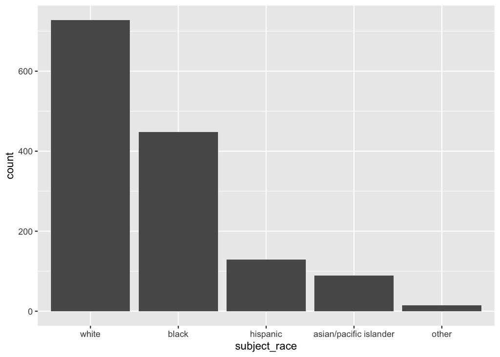

```r
evp$subject_race <- forcats::fct_infreq(evp$subject_race)
ggplot(evp, aes(x=subject_race)) +
  geom_bar()
```

## Caution

If you try to change the value of a variable that is a factor to something that isn’t one of the factor levels, you will introduce missing values into your data:

```r
my_colors <- factor(c("red", "blue", "green", "red", "red", "blue", "green"))
my_colors
```

```
## [1] red   blue  green red   red   blue  green
## Levels: blue green red
```

```r
my_colors[1] <- "pink"
my_colors
```

```
## [1] <NA>  blue  green red   red   blue  green
## Levels: blue green red
```

To avoid this issue, usually the easiest thing to do is to convert the variable to be of character type before changing the values, and then re-make the factor if you need:

```r
my_colors <- as.character(my_colors)
my_colors[1] <- "pink"
my_colors <- factor(my_colors)
my_colors
```

```
## [1] pink  blue  green red   red   blue  green
## Levels: blue green pink red
```

Also, the default order for factors can be different in different places in the world. To avoid this issue, either explicitly set the levels for any factor you create or use the forcats package to create a factor instead of the default `factor()` function.

# Counting with sum()

It’s often useful to count how many observations meet some criteria. For example, how many of the drivers in the `evp` data are female? Or how many penguins have a bill length of more than 43 mm. `table()` is one option when you just need the frequency of a value, but for the question of bill length, a table won’t work.

Instead, like we did with counting missing values, we can use `sum()` to count the number of TRUE values.

```r
penguins$bill_length_mm > 43
```

```
##   [1] FALSE FALSE FALSE    NA FALSE FALSE FALSE FALSE FALSE FALSE FALSE FALSE
##  [13] FALSE FALSE FALSE FALSE FALSE FALSE FALSE  TRUE FALSE FALSE FALSE FALSE
##  [25] FALSE FALSE FALSE FALSE FALSE FALSE FALSE FALSE FALSE FALSE FALSE FALSE
##  [37] FALSE FALSE FALSE FALSE FALSE FALSE FALSE  TRUE FALSE FALSE FALSE FALSE
##  [49] FALSE FALSE FALSE FALSE FALSE FALSE FALSE FALSE FALSE FALSE FALSE FALSE
##  [61] FALSE FALSE FALSE FALSE FALSE FALSE FALSE FALSE FALSE FALSE FALSE FALSE
##  [73] FALSE  TRUE FALSE FALSE FALSE FALSE FALSE FALSE FALSE FALSE FALSE FALSE
##  [85] FALSE FALSE FALSE FALSE FALSE FALSE FALSE FALSE FALSE FALSE FALSE FALSE
##  [97] FALSE FALSE FALSE  TRUE FALSE FALSE FALSE FALSE FALSE FALSE FALSE FALSE
## [109] FALSE  TRUE FALSE  TRUE FALSE FALSE FALSE FALSE FALSE FALSE FALSE FALSE
## [121] FALSE FALSE FALSE FALSE FALSE FALSE FALSE FALSE FALSE  TRUE FALSE  TRUE
## [133] FALSE FALSE FALSE FALSE FALSE FALSE FALSE FALSE FALSE FALSE FALSE FALSE
## [145] FALSE FALSE FALSE FALSE FALSE FALSE FALSE FALSE  TRUE  TRUE  TRUE  TRUE
## [157]  TRUE  TRUE  TRUE  TRUE  TRUE  TRUE FALSE  TRUE  TRUE  TRUE  TRUE  TRUE
## [169] FALSE  TRUE  TRUE  TRUE  TRUE  TRUE  TRUE  TRUE FALSE  TRUE  TRUE  TRUE
## [181]  TRUE  TRUE  TRUE FALSE  TRUE  TRUE  TRUE  TRUE FALSE  TRUE  TRUE  TRUE
## [193] FALSE  TRUE  TRUE  TRUE  TRUE  TRUE  TRUE  TRUE  TRUE  TRUE  TRUE  TRUE
## [205]  TRUE  TRUE  TRUE  TRUE  TRUE  TRUE  TRUE  TRUE  TRUE  TRUE  TRUE  TRUE
## [217]  TRUE  TRUE  TRUE  TRUE  TRUE  TRUE  TRUE  TRUE  TRUE  TRUE  TRUE  TRUE
## [229]  TRUE  TRUE  TRUE  TRUE  TRUE  TRUE  TRUE  TRUE  TRUE  TRUE  TRUE  TRUE
## [241]  TRUE  TRUE  TRUE  TRUE  TRUE  TRUE  TRUE  TRUE  TRUE  TRUE  TRUE  TRUE
## [253]  TRUE  TRUE  TRUE  TRUE  TRUE  TRUE FALSE  TRUE  TRUE  TRUE  TRUE  TRUE
## [265]  TRUE  TRUE  TRUE  TRUE  TRUE  TRUE  TRUE    NA  TRUE  TRUE  TRUE  TRUE
## [277]  TRUE  TRUE  TRUE  TRUE  TRUE  TRUE  TRUE  TRUE  TRUE  TRUE  TRUE  TRUE
## [289]  TRUE  TRUE  TRUE  TRUE  TRUE  TRUE  TRUE  TRUE FALSE  TRUE  TRUE  TRUE
## [301]  TRUE  TRUE  TRUE  TRUE  TRUE  TRUE FALSE  TRUE FALSE  TRUE  TRUE  TRUE
## [313]  TRUE  TRUE  TRUE  TRUE  TRUE  TRUE  TRUE  TRUE  TRUE  TRUE  TRUE  TRUE
## [325]  TRUE  TRUE  TRUE  TRUE  TRUE  TRUE FALSE  TRUE  TRUE  TRUE  TRUE  TRUE
## [337]  TRUE  TRUE  TRUE  TRUE  TRUE  TRUE  TRUE  TRUE
```

```r
sum(penguins$bill_length_mm > 43)
```

```
## [1] NA
```

```r
sum(penguins$bill_length_mm > 43, na.rm=TRUE)
```

```
## [1] 188
```

If we want to compute that as a proportion:

```r
sum(penguins$bill_length_mm > 43, na.rm=TRUE)/nrow(penguins) ## all penguins
```

```
## [1] 0.5465116
```

```r
sum(penguins$bill_length_mm > 43, na.rm=TRUE)/sum(!is.na(penguins$bill_length_mm)) ## non-missing values
```

```
## [1] 0.5497076
```

## EXERCISE

You can do these with `sum()` but there are other methods that will work as well.

How many drivers in the `evp` data are “white”?

How many drivers in the `evp` data are “white” and “female”?

Remember: you can use `names(evp)` to see what the column names are.

Challenge: What proportion of Gentoo penguins have a body mass over 6000g?

# Basic Plots

I recommend using the ggplot2 package for data visualization (separate workshop), but it’s useful to know how to make a few basic plots without it.

## hist

You can make a histogram with the `hist()` function. Visualizing the distribution of any continuous variable is always a good idea.

`mtcars` is a built-in data frame

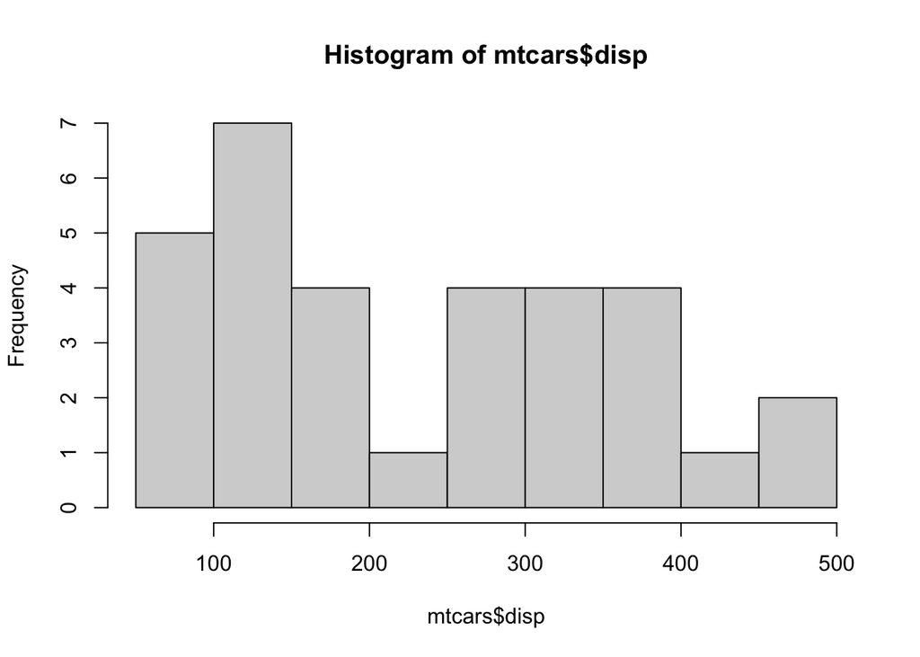

```r
hist(mtcars$disp)
```

Control the number of bars

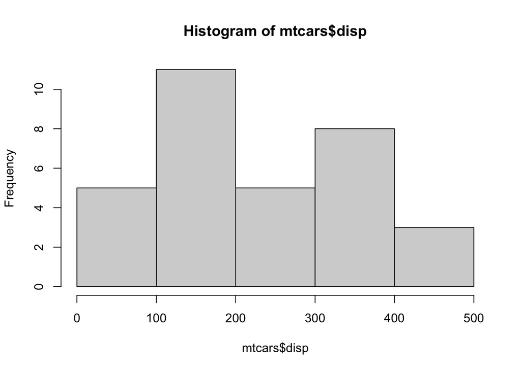

```r
hist(mtcars$disp, breaks=5)
```

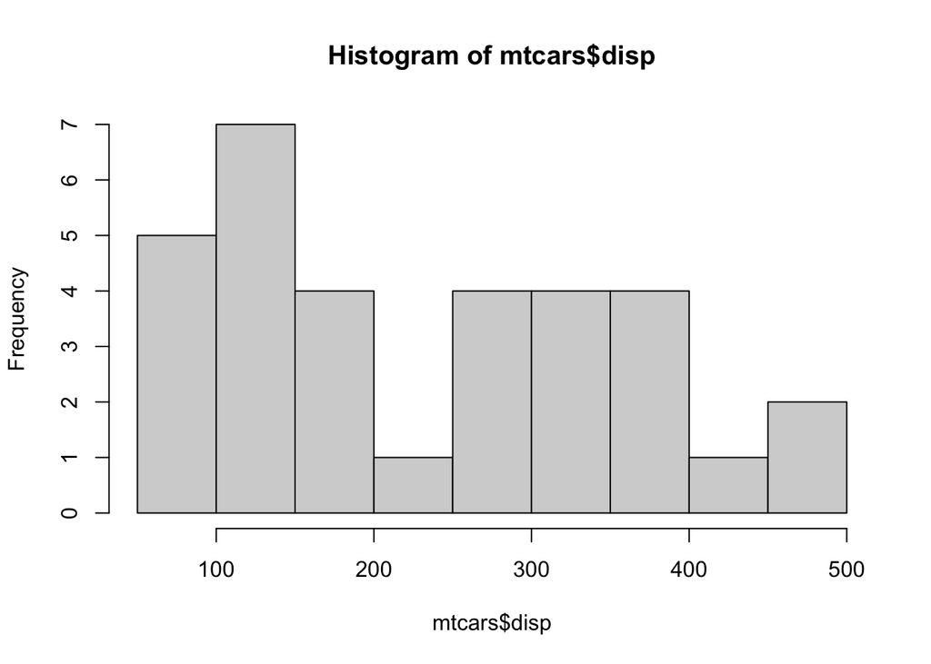

```r
hist(mtcars$disp, breaks=6)
```

But it has a bias towards even break points. You can control the breaks precisely if you do need to.